# Lab 2: Impact of Government Interventions on COVID-19 deaths

Carolina Arriaga, Sunit Carpenter, Heather Rancic

# Introduction

The year 2020 is known as the worst year in memorable history. When the first wave of Covid-19 hit the U.S. in full force in March of 2020, the U.S. government did not have a plan on how to handle a pandemic.

State governors were left to fend largely for themselves with little Federal government guidance or relief. They individually made decisions to provide protection and guidance to their constituents in order to keep them safe amidst the covid-19 pandemic whilst trying to keep businesses afloat and manage the economy to the best of their abilities. Individual states have opened and closed businesses, required masks, and taken other measures with varying degrees of success. Because of this, it’s difficult to ascertain what works, what doesn’t, and what the impact of those well intentioned measures are on covid-19 cases.

It is critical that we reach a deeper understanding of these differences in order to respond with appropriate public policies. Our team will clean and analyse data to see what patterns we can find that can help inform U.S. state governors as they seek guidance on what policies are effective and to help them to make the best decisions possible for their constituents. We recognize that the data will not be as perfect as we would like. We plan to clean the data in order to enable a conformed dataset to ensure our research is performed with scientific rigor and integrity to the best of our ability. The plan is to take into account differences between states but also see what correlations we can find overall across the U.S by leveraging data across 4/12/2020 through 3/25/2021.

## Research Question

We want to understand if state level government interventions are correlated with Covid-19-deaths. We defined government interventions as mask required in public, shelter in place, quarantine for travellers as it relates to covid-19 deaths.

**Our research question is: Is there an impact from government interventions on covid-19 death toll?**

A Structural Equation Model was created to understand the relationship between the Covid-19 death toll and other factors, including the mandates (Fig 1).

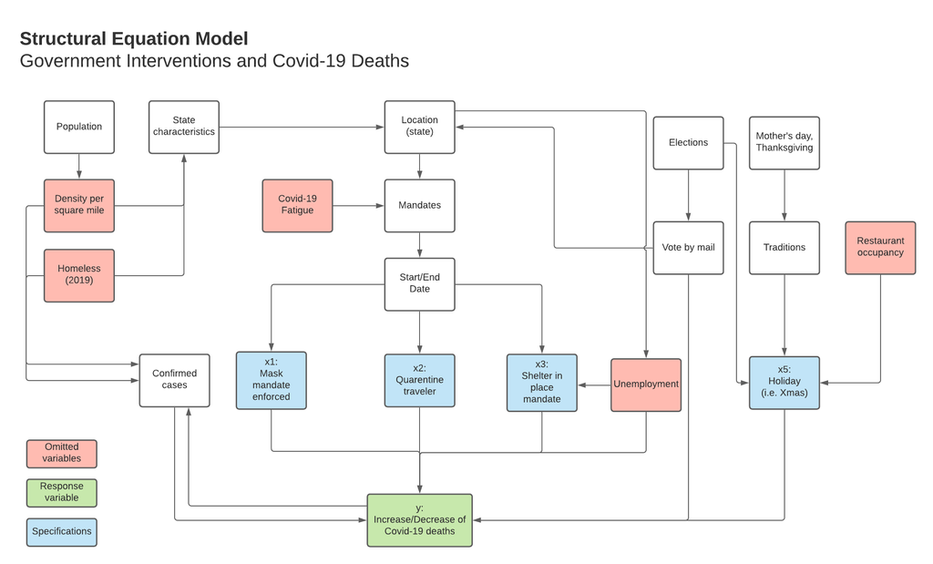

*Fig 1: Structural Equation Model for Covid-19 deaths and government interventions.*

After completing the SEM, we considered also two subquestions:

- Is the period of +/- fifteen days prior to and after a holiday increasing the Covid-19 deaths?
- Is the population density influencing Covid-19 deaths?

From all the US holidays, we focused this study on three of them: Mother’s day, Election day and Thanksgiving. We selected Mother’s day because it’s an important US holiday that occurred early in the pandemic, we chose election day because we expected many people might ignore recommended mandates in order to vote in person which may have an impact in Covid-19 deaths, and we picked Thanksgiving because it’s the most popular travel holiday in the US.

Mandates were not enforced in multiple states consistently during the holidays. We calculated the death toll during a holiday period by subtracting the death toll at the end and start dates. Then we evaluated the effect of the mandates. For each covariate, we aggregated the total days when the mandate was in effect.

For example, the case when the mandate is enforced from the holiday to the next three days was considered as a total of four days.

# Model Building Process

## Data

In order to answer the research question, our team has gathered information from the following sources which are described below:

- The raw data was sourced from [COVID-19 Data Repository](https://github.com/CSSEGISandData/COVID-19/tree/master/csse_covid_19_data) by the Center for Systems Science and Engineering (CSSE) at Johns Hopkins University [1]. Data columns we are considering for our study:

Table 1. Filtered raw data from source

| spec | description |
| --- | --- |
| US State | US State name or district |
| Date | Date in format MM/DD/YYYY |
| Covid-19 Cases | Counts include confirmed and probable (where reported) |
| Mask mandate enforced - start | Date in format MM/DD/YYYY |
| Mask mandate enforced - end | Date in format MM/DD/YYYY |
| Shelter in place - start | Date in format MM/DD/YYYY |
| Shelter in place - end | Date in format MM/DD/YYYY |
| Quarantine for travelers - start | Date in format MM/DD/YYYY |
| Quarantine for travelers - end | Date in format MM/DD/YYYY |
| Population | Population from 2018 |
| Density | Population per square mile |
| Elected party | State results in 2020 presidential elections |

- Holidays were taken from the python-holidays module.
- State results from presidential election were taken from [wikipedia](https://en.wikipedia.org/wiki/2020_United_States_presidential_election).

## Data Loading

We wrangled the data to achieve the following structure:

Table 2. Processed data from raw data

| spec | description |
| --- | --- |
| US State | US State name or district |
| Covid-19 Cases | Case count for the state per 100k people |
| Deaths | Death toll for the state per 100k people |
| Mask in public | Aggregated days when mask in public mandate was required (end date - start date) |
| Shelter in place | Aggregated days when shelter in place was enforced (end date - start date) |
| Quarantine for travellers | Aggregated days when Quarantine for travellers was enforced (end date - start date) |
| Density | Population per square mile |
| Party | Democrat or Republican |

## Data Wrangling

The raw data included a full year across US States. We sliced the data specifically specifically for the three aforementioned holidays. We considered population density as it relates the three holidays we chose to study.

The population density might affect how fast the virus spreads. We divided the states in three groups: High, Med, Low. High density includes all the states with more than 200 people per square mile, then med density is the interval between a 100 and 199, and low density is any value less than 100.

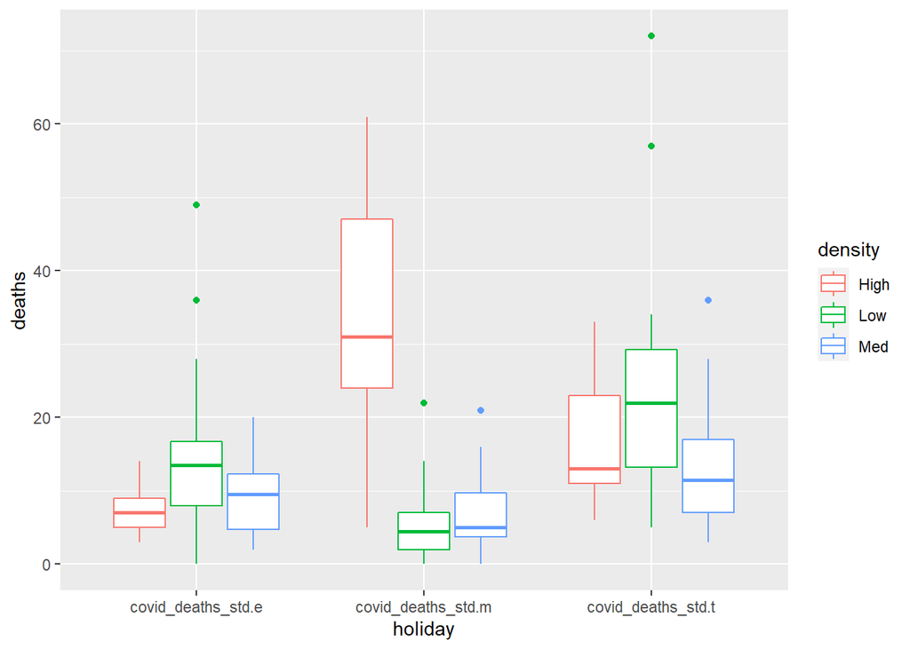

*Figure 2. Death toll during Election day, Mother’s day and Thanksgiving.*

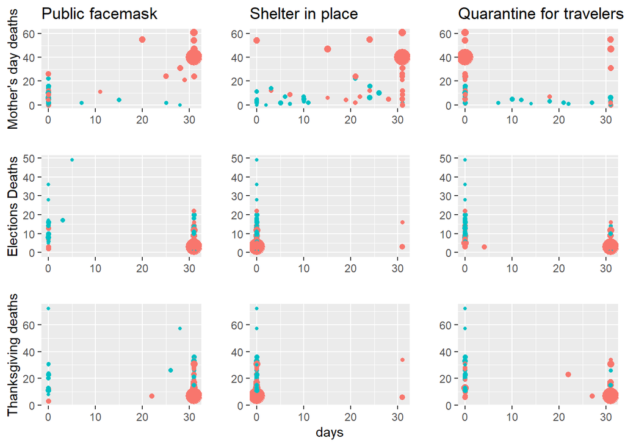

*Figure 3. Death toll during multiple holidays and relationship to Public face mask, shelter in place, and quarantine for travelers mandates.*

We focused on a specific holiday, such as mother’s day. The reason for focusing on this particular period of time is because we can see how multiple states were implementing interventions during the 30 days (holiday +/- 15 days). As we can see in the other holidays, the interventions become more binary (zero or the max value), sometimes with very few observations in each of them.

For example, the shelter in place with only two states (California and New Mexico) with the mandate effective. We don’t believe that would be a representative option to measure the impact of that intervention. This study will cover only the Mother’s day period. California is a state with the highest population. New Mexico is the poorest state in the USA and with less hospitals and beds for Covid-19 patients [9].

## Study Design

We want to measure the impact of government interventions in the Covid-19 death toll during the Mother’s day period. Each observation will be recorded at a state level. The model will be created by 51 observations, each of them composed of the following features:

Table 2. Processed data from Mother’s day

[output not shown]

## Model goals

Three models seek to explain the impact of government interventions considering the specifications stated in the SEM in Figure 1, which showed the theoretical relationships between the increase or decrease of Covid-19 deaths and multiple factors. The heatmap below shows similar patterns by Covid-19 deaths and cases. We’ve chose deaths as our response variable because we believe there’s a smaller variation embedded in how the deaths were recorded compared to Covid-19 cases across all the USA.

It must be flagged here that Oregon changed the way they reported the total cases of confirmed cases and switched from number of tests to number of persons tested. There is a lot of variation from state to state that is linked to different approaches when measuring total cases. For this reason, we decided to use the variable of death toll instead of confirmed cases.

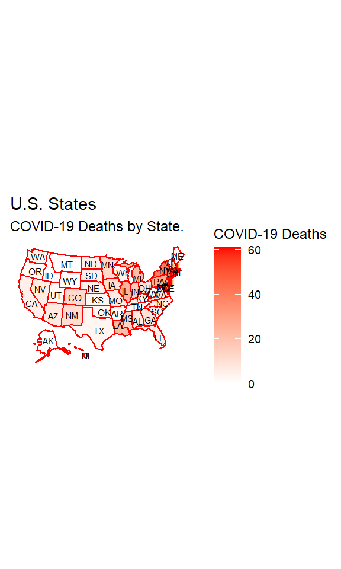

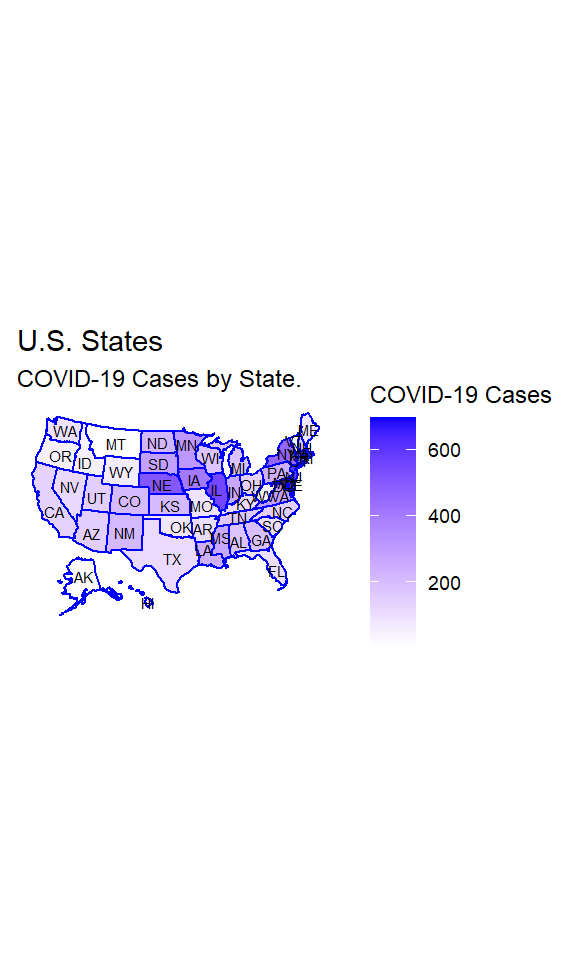

*Figure 4. (Left) Death toll by state. (Right) Covid-19 cases by state.*

### Model 1: Limited model

The mask mandate has been subject to controversy since the pandemic started, having multiple countries and the WHO providing multiple standards on face mask use in community settings [2]. We believe that there is a negative correlation between Covid-19 deaths and the total days the mask in public mandate was required.

$$y = D = \beta_0 + \beta_1M$$

### Model 2: Extended model

The extended model includes the rest of the government interventions which are shelter in place and quarantine for travelers. We believe that during the holiday season, the mobility was increased in all the states. Is not always the case that the interventions coincided with the holidays. If our original intuition about mask mandate has a large effect, we expect to see that in the holidays when people had a higher interaction and consequentially, the Covid-19 deaths would be reduced if more interventions were in place. In all of the variables proposed in the extended model we expect a negative correlation to the response variable.

$$y = D = \beta_0 +\beta_1M +\beta_2S +\beta_3Q$$

### Model 3: Full model

The full model will take into account the political party the state voted during 2020 elections. We chose this variable because democratic states supported the introduction of government interventions in a larger degree compared to republican states:

$$y = D = \beta_0 +\beta_1M +\beta_2S +\beta_3Q + + \beta_4P$$

## Statistical Methods

### EDA

Before running the proposed models, we looked the correlation matrix of the variables of interest.

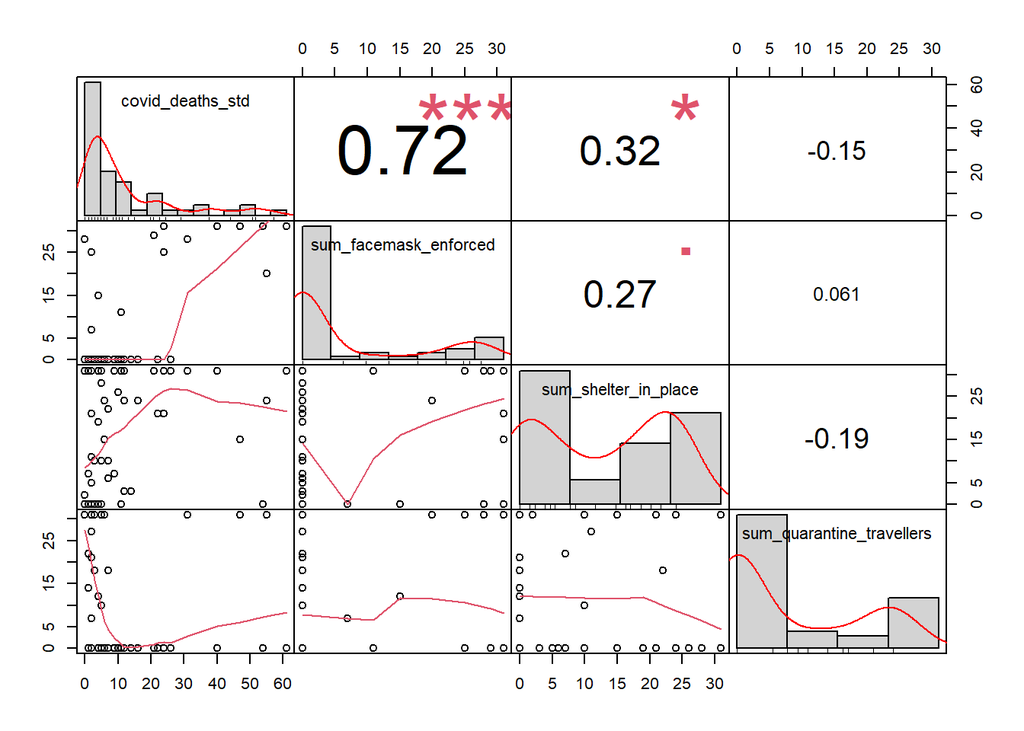

*Figure 5. Correlation matrix for death toll, public face mask, shelter in place, and quarantine for travelers during Mother’s day.*

#### Facemask required in public spaces

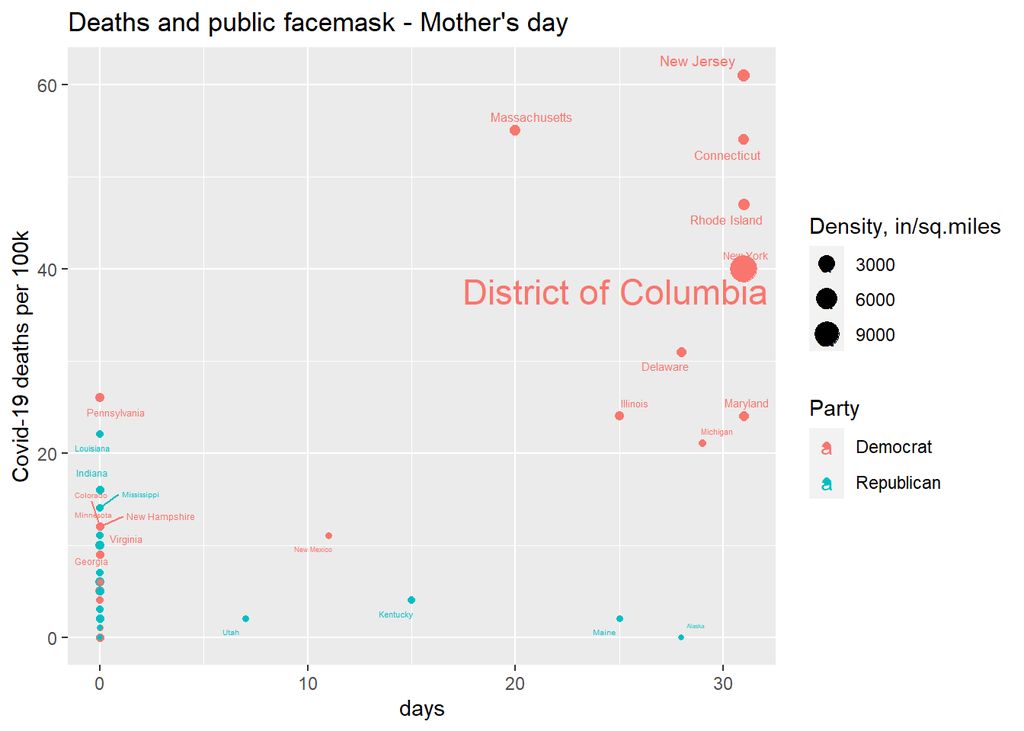

*Figure 6. Relationship between death’s and effective days of public face masks.*

The states with lowest Covid-19 deaths are Hawaii, Alaska, Maine, Vermont and Oregon. They all seem to have a similar population density except for Alaska. Hawaii is naturally isolated to the rest of the US States. It might even be considered an outlier in terms of connectivity with the rest of the states [3].

It is evident that states with the highest density seem to land towards the top right of the plot (Figure 6). We can also notice that most of the democratic states had a longer public face mask mandate requirement period while the majority of republican states didn’t required it.

#### Shelter in place

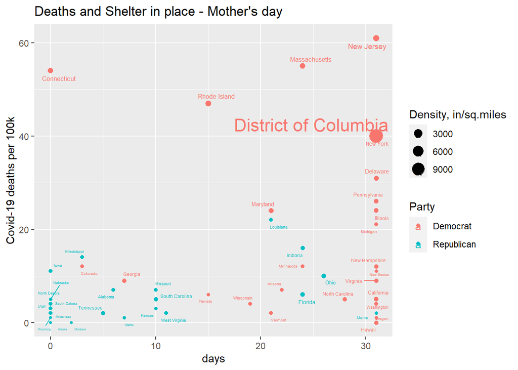

*Figure 7. Relationship between death’s and effective days of shelter in place.*

#### Quarantine for travellers

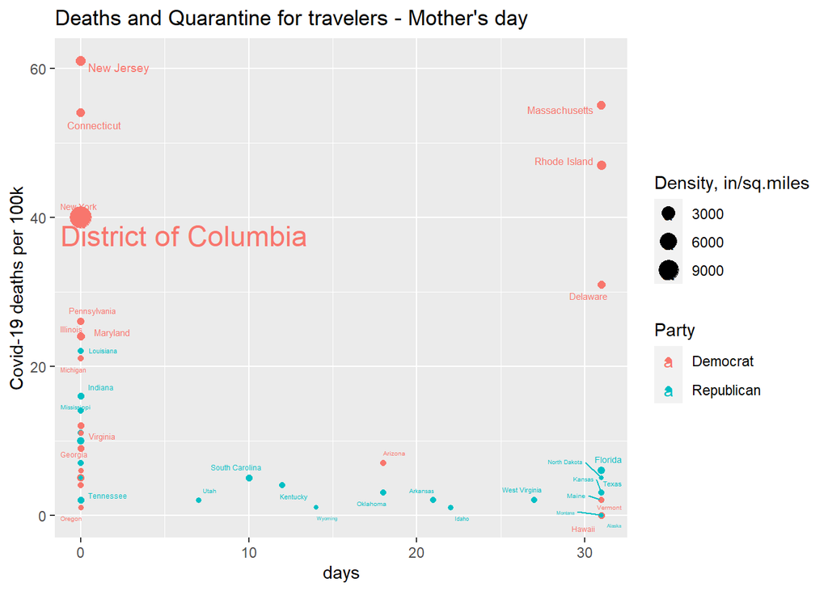

*Figure 8. Relationship between death’s and effective days of quarantine for travelers.*

#### Party Elected in 2020 President Election

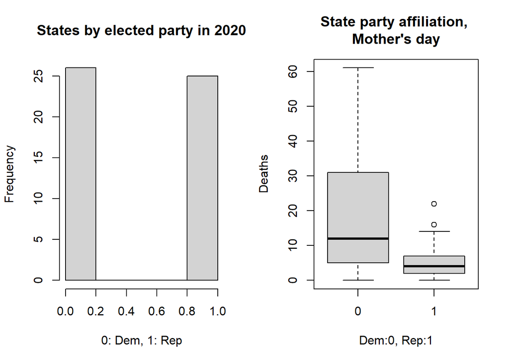

*Figure 9. (Left) Histogram of state affiliation. Figure 10. (Right) Distribution of death’s by party affiliation in 2020 presidential elections.*

The histogram shows that the states are almost evenly divided by Republican versus Democrat, where the latter has a minor lead (+1). Democrats have a larger average death toll and a wider distribution compared to Republicans. We also want to point at the impact of high population density may be the reason for such variation (Figure 7) because all the highest population states are democratic.

# Regression Table

### Model 1: Optimized Limited model

To reduce standard errors we modeled the public face mask required variable as a second degree polynomial. We observed that the residuals didn’t have a significant deviaiton from zero after the optimization (Figure 11).

$$y = D = \beta_0 + \beta_1M + \beta_2M^2$$

### Model 2: Optimized Extended model

The extended model was optimized by modeling the shelter in place variable as a second degree polynomial, residuals showed a smaller deviation from zero.

$$y = D = \beta_0 +\beta_1M + \beta_2M^2 +\beta_3S +\beta_4S^2 +\beta_5Q$$

### Model 3: Full model

We kept the model two and added the party affiliation variable as planned.

$$y = D = \beta_0 +\beta_1M + \beta_2M^2 +\beta_3S +\beta_4S^2 +\beta_5Q + \beta_6P$$
After analyzing the variance inflation, we decided to drop the variable shelter in place creating an optimized model three.

$$y = D = \beta_0 +\beta_1M + \beta_2M^2 +\beta_5Q + \beta_6P$$

We present the results of the three models studied.

```
##
## ==========================================================================================
##                                               Dependent variable:
##                       --------------------------------------------------------------------
##                                         Death toll per 100k inhabitants
##                                 M                    M+S+Q                  M+Q+P
##                                (1)                    (2)                    (3)
## ------------------------------------------------------------------------------------------
## mask in public                -0.451                 -0.082                 -0.216
##                              (1.550)                (1.695)                (1.516)
##
## mask in public sqrd           0.047                  0.035                  0.036
##                              (0.051)                (0.056)                (0.052)
##
## shelter in place                                     0.753
##                                                     (0.780)
##
## shelter in place sqrd                                -0.021
##                                                     (0.024)
##
## quarantine travelers                                 -0.194                 -0.134
##                                                     (0.136)                (0.154)
##
## party                                                                       -5.926
##                                                                            (4.339)
##
## Constant                     6.802***                4.992                11.515***
##                              (1.018)                (4.287)                (2.476)
##
## ------------------------------------------------------------------------------------------
## optimized model                Yes                    Yes                    Yes
## Observations                    51                     51                     51
## R2                            0.548                  0.599                  0.605
## Adjusted R2                   0.529                  0.554                  0.570
## Residual Std. Error      10.681 (df = 48)       10.388 (df = 45)       10.198 (df = 46)
## F Statistic           29.043*** (df = 2; 48) 13.431*** (df = 5; 45) 17.596*** (df = 4; 46)
## ==========================================================================================
## Note:                                                          *p<0.1; **p<0.05; ***p<0.01
```

# Model Limitations

## IID

Each state is geographically dependent of the neighbors and political affiliations. Even when interventions were in place by the government, there is no way to know if the people followed the guidelines en mass. The model hardly complies with this requirement, however we consider for this study that the sample is representative of the USA population at the time period of data collection used in the study and the sample size can be considered not small.

## Linearity

For the model one, we have only one specification: mask required in public. We found the residuals had a parabolic trend. For model two we shelter in place residuals were also parabolic. The linearity assumptions was threaten and we optimized the model modeling public face mask and shelter in place as polynomials of second degree. See Figure 11 for model three optimized model plots.

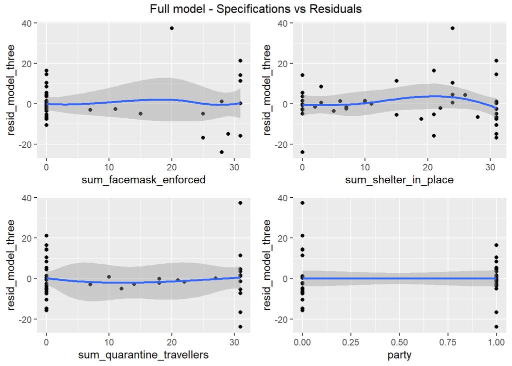

*Figure 11. Specifications vs residuals for optimized model three.*

## No perfect collinearity

We know the variables chosen didn’t have perfect collinearity because we were able to run the model without singularity problems. Also, we analyzed in the full model which variable is bringing the most inflation to our predictions. Public face mask and shelter in place are both increasing the model variation significantly. We decided to drop shelter in place from model three to optimize the error in the model. We kept public face mask because it’s the variable of interest in this study.

After droping the shelter in place specification from model three a slight improvement in the R square adjusted was obtained.

## Homoskedastic errors

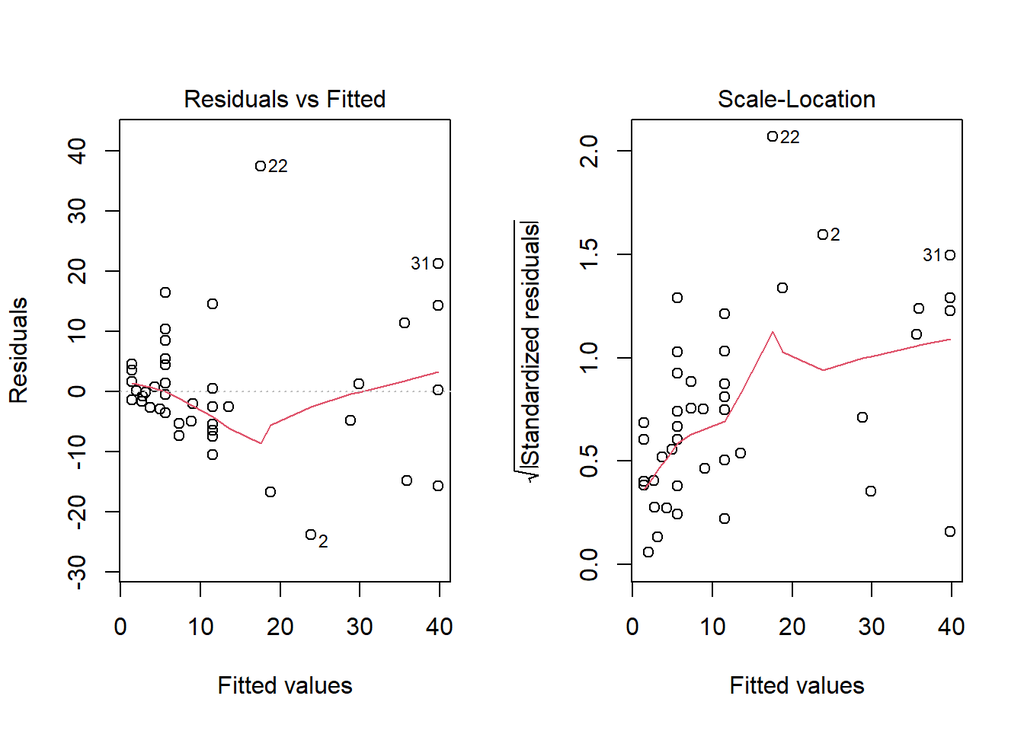

*Figure 12. (Left) Residuals vs Fitted for optimized model three show deviation in the middle. Figure 13. (Right) Scale-Log shows a constant increase in the standardized residual values as the fitted value increases.*

## Normality of errors

The qq-plot shows that the errors are not normally distributed in both ends of the tail for values less than -1 and 1. The validity of the standard errors reported in this study is threatened.

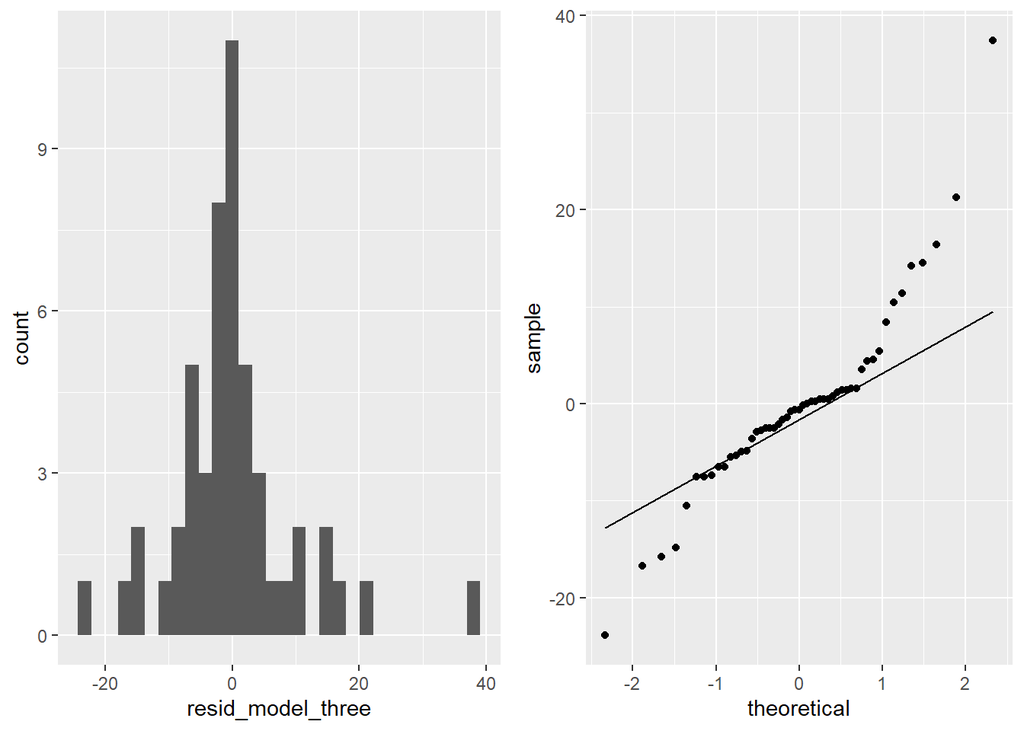

*Figure 14. (Left) Residuals histogram for model three. Figure 15. (Right) QQ-Plot of residuals of optimized model three.*

## zero conditional mean

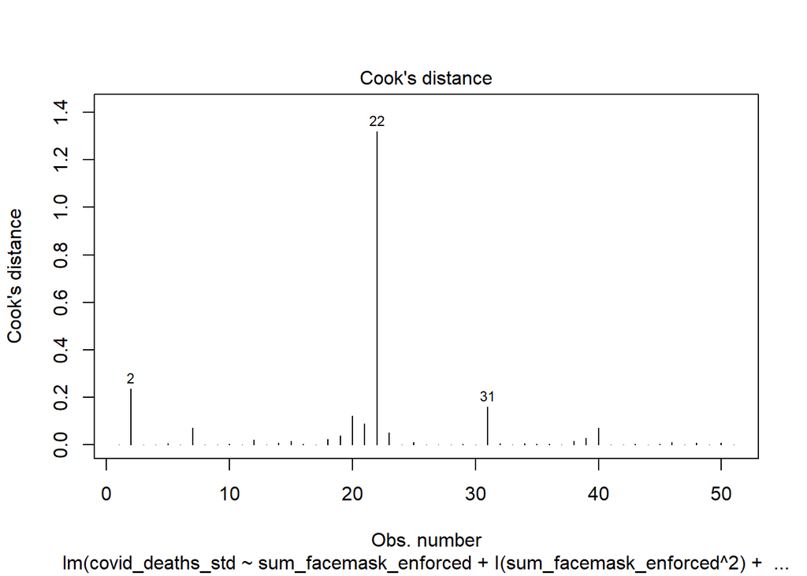

*Figure 16. Cook’s D for optimized model three.*

# Discussion of Omitted Variables

We believe that there are multiple factors at play when it comes to considerations around COVID-19 deaths. It is likely that our models are biased due to omitted variables. We listed out those variables as possible limitations to our models.

**Density per square mile (d)**

We were not able to get accurate current data on the population density for all of the states. Also, getting the population density of a given state may not give us a true picture of the population density. For example, majority of the people in Nevada live in the Las Vegas area. Nevada has a low population density at the state level, but in reality has a much higher population density as the population is concentrated around the city of Las Vegas. Covid-19 infection is spread by close contact with infected people and higher the population density leads to higher rate of infection and death. [6].

D = M, OV=d D&M (-), D&d(+), M&d(+) Away from zero, large

**Restaurant occupancy (r)**

Restaurants were closed by mandate inconsistently across states. Even for those restaurants that were ordered to close, some businesses chose to defy the guidance and opened anyway. The volume of patrons visiting restaurants during Mother’s day, may have influenced the spread and deaths related to Covid-19.

D = M, OV=r D&M (-), D&e (+), M&r (-) Towards zero, small

**Unemployment (u)**

The US unemployment rate peaked at 14.8% in April, 2020. [8] Millions of people lost their jobs and were not able to work. We do not have data on the impact of people not being able to go to work on the Covid-19 infections. If the umemployed stayed at home, they had the potential of infecting others in the household. On the other hand, by staying at home, the unemployed had less exposure to Covid-19 compared to physically going to work in an office/restaurant type environment.

D = M, OV=u D&M (-), D&u (-), M&u (-) Towards zero, small

**Homelesness (h)**

We do not have data on the homeless population for each state and how they potentially contributed to the spread of Covid-19 infections. Also, homeless people are less likely to have the resources to purchase masks and other means of protection from Covid-19 infections. We also do not have the data on location of the homeless population - urban or rural areas.

D = M, OV=h D&M (-), D&h (+), D&h (+) Away zero, small

**Covid-19 Fatigue (f)**

While it is difficult to measure Covid-19 fatigue, as the pandemic wore on, people had increased difficulty with social distancing. People began to weigh mental health impact on isolation vs. the risk of following safety guidelines in favor of ignoring safety guidelines. We saw evidence of this from people gathering for spring break and end of year holidays such as Thanksgiving and Christmas.

D = M, OV=f D&M (-), D&f (+), M&f (+) Away zero, large

Table 3. Omitted variable bias for optimized model three.

| OV | Bias | Effect_size |
| --- | --- | --- |
| Density per square mile | Away from zero | Large |
| Restaurant occupancy | Toward zero | Small |
| Unemployment | Toward zero | Small |
| Homelessness | Away from zero | Small |
| Covid-19 Fatigue | Away from zero | Large |

# Conclusion

After evaluating three models and optimized them to comply with the classical linear model assumptions, we found the model three was the best. The optimized model three used only data from mother’s day (+/- 15 days), a time relatively early in the pandemic when guidelines in multiple states were in place and people were heeding the guidelines.

The optimized model three considered public face mask mandate, quarantine for travelers and the affiliated party during the presidential election as covariates. We encountered threats to validity of the standard error, F-test, t-value and p-value due to homoskedastic error and fail to comply with normality of errors. The results of this study will focus only in the coefficients of the input variables of the optimized model three.

$$y = D = 11.51 -0.22\cdot M_d + 0.04 \cdot M_d^2 -0.13 \cdot Q_d -5.92 \cdot P_d \qquad (1)$$

Having said that, we must emphasize that our optimized model three is not a good estimator for deaths. The R square adjusted is low, with a value of 0.57, meaning that there’s a large amount of variation not explained by our model.

# References

[1] Dong E, Du H, Gardner L. An interactive web-based dashboard to track COVID-19 in real time. Lancet Inf Dis. 20(5):533-534. doi: 10.1016/S1473-3099(20)30120-1

[2] Feng et al. (2020, March). Rational use of face masks in the COVID-19 pandemic. Retrieved April 05, 2021, from https://www.thelancet.com/journals/lanres/article/PIIS2213-2600(20)30134-X/fulltext

[3] https://time.com/5915084/hawaii-covid-coronavirus/

[4] https://www.bloomberg.com/news/articles/2021-01-06/n-y-s-neighbor-keeps-cases-lowest-in-u-s-throughout-pandemic

[5] https://www.wweek.com/news/2020/12/23/oregon-fares-better-than-nearly-all-states-by-two-key-covid-19-measures/

[6] https://www.cdc.gov/coronavirus/2019-ncov/prevent-getting-sick/how-covid-spreads.html [7] http://electionlab.mit.edu/sites/default/files/2020-12/How-we-voted-in-2020-v01.pdf [8] https://fas.org/sgp/crs/misc/R46554.pdf

[9] https://www.nytimes.com/2020/04/24/us/coronavirus-new-mexico.html

[10] https://www.npr.org/2020/10/24/927384374/rural-midwestern-communities-hit-hard-as-coronavirus-surges-in-u-s-again